# Ecology 8540 Computational Workshops

May 23, 2021  
Materials at https://github.com/CEIDatUGA/ECOL8540-datavis

## Maps

[figure not shown]

Henricus Martelus, WORLD MAP, c1490

[figure not shown]

John Snow: Mapped positions of deaths from cholera in London.  
The map revealed a cluster of cases around a water pump, with density of cases  
decreasing with distance from the pump. 1854.

[figure not shown]

Charles Booth: Descriptive map of London poverty, 1889. [info](https://commons.wikimedia.org/wiki/File:Descriptive_map_of_London_poverty,_1889_Wellcome_L0074435.jpg)

[interactive chart not shown]

https://earth.nullschool.net

## Map Projections

A **Projection** is a systematic (mathematical) “stretching” of the surface of the sphere onto a flat plane. Every projection preserves some aspects of the geometry and distorts other aspects.

Therefore, there is no truthful map of the earth.

**3 categories of Map Projections:**

- Azimuthal
  - Preserves direction and distance
- Equal Area
  - Preserves area
- Conformal
  - Preserves local angles (straight lines on the sphere look straight on the plane.)

[Wikipedia: Map Projections](https://en.wikipedia.org/wiki/Map_projection)

## Map Projections

- Azimuthal (Preserves direction and distance)
  - [example: “Azimuthal Equidistant”](http://en.wikipedia.org/wiki/Azimuthal_equidistant_projection)

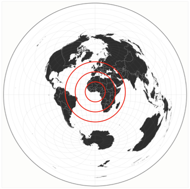

## Map Projections

- Equal Area (Preserves area)
  - [example: “Albers Equal Area Conic”](http://en.wikipedia.org/wiki/Albers_projection)

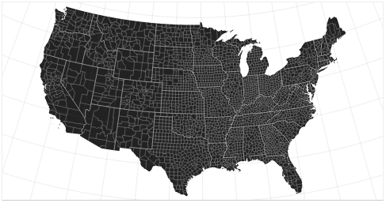

https://observablehq.com/@d3/conic-equal-area

## Map Projections

- Conformal (Preserves local angles)
  - [example: “Peirce Quincuncial”](http://en.wikipedia.org/wiki/Peirce_quincuncial_projection)

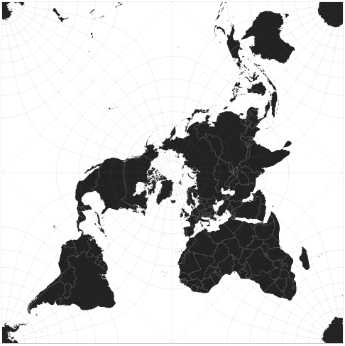

https://observablehq.com/@d3/peirce-quincuncial

## Map Projections

- Conformal (Preserves local angles)
  - [example: “Mercator”](http://en.wikipedia.org/wiki/Mercator_projection)

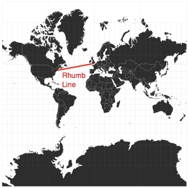

https://observablehq.com/@d3/mercator

## Map Projections: [Tissot’s Indicatrix](https://en.wikipedia.org/wiki/Tissot%27s_indicatrix)

[figure not shown]

Orthographic

[figure not shown]

Azimuthal Equidistant

[figure not shown]

Mercator

[figure not shown]

Peirce Quincuncial

[figure not shown]

Albers

[figure not shown]

Dymaxion (https://en.wikipedia.org/wiki/Dymaxion_map)

[figure not shown]

Human migrations according to mitochondrial population genetics (millennia before present)

[figure not shown]

http://xkcd.com/977

## Map Scale

**For a small area, earth’s curvature can be ignored, and a map can use a single scale.**

**For a large area, map projections cause any scale to be variable**

[figure not shown]

**Scale is often expressed as a ratio without units**

1:250,000

This concept is borrowed from print, where the dimensions of a printed map are constant. For screen, since the physical dimensions of the image can vary with the screen, ratio scales are less useful. Therefore, online, we tend to use graphic scale bars.

## Map Scale

**Content should be appropriate to the scale.**

[figure not shown]

Modern mapping tools can dynamically control what content is visiable at each scale level, automatically.

## Map Types

- Symbol Maps
  - Dot Map
  - Bubble Map
- Continuous Data
  - Heatmaps
  - Choropleth
- Cartograms
- Flow Maps

## Map Types

- Symbol Maps
  - Dot Map
  - Bubble Map
- Continuous Data
  - Heatmaps
  - Choropleth
- Cartograms
- Flow Maps

[figure not shown]

## Map Types

- Symbol Maps
  - Dot Map
  - Bubble Map
- Continuous Data
  - Heatmaps
  - Choropleth
- Cartograms
- Flow Maps

[figure not shown]

## Map Types

- Symbol Maps
  - Dot Map
  - Bubble Map
- Continuous Data
  - Heatmaps
  - Choropleth
- Cartograms
- Flow Maps

[figure not shown]

Most photographed areas

## Map Types

- Symbol Maps
  - Dot Map
  - Bubble Map
- Continuous Data
  - Heatmaps
  - Choropleth
- Cartograms
- Flow Maps

[figure not shown]

Australian_Census_2011: Anglicans as a proportion of the population

## Map Types

- Symbol Maps
  - Dot Map
  - Bubble Map
- Continuous Data
  - Heatmaps
  - Choropleth
- Cartograms
- Flow Maps

[figure not shown]

## Map Types

- Symbol Maps
  - Dot Map
  - Bubble Map
- Continuous Data
  - Heatmaps
  - Choropleth
- Cartograms
- Flow Maps

[figure not shown]

## Map Types

- Symbol Maps
  - Dot Map
  - Bubble Map
- Continuous Data
  - Heatmaps
  - Choropleth
- Cartograms
- Flow Maps

https://en.wikipedia.org/wiki/Cartogram

[figure not shown]

## Map Types

- Symbol Maps
  - Dot Map
  - Bubble Map
- Continuous Data
  - Heatmaps
  - Choropleth
- Cartograms
- Flow Maps

Flow maps display flows (vectors fields: direction and magnitude)  
https://earth.nullschool.net

[interactive chart not shown]

## Tools:

raster vs shape data

rgdal, sp